# Larval size analysis - Mcap 2020

AS Huffmyer

# Set Up

Set up workspace, set options, and load required packages.

```r
knitr::opts_chunk$set(echo = TRUE, warning = FALSE, message = FALSE)
```

# Import and manipulate data

```r
# Larval size data
size <- read_csv("Mcap2020/Data/Physiology/Size/larval_size.csv")

#metadata
metadata <- read_csv("Mcap2020/Data/lifestage_metadata.csv")

size <- left_join(size, metadata)
size$hpf <- as.factor(size$hpf)
```

## Prep data frame, considering each individual larvae as a replicate here, not summarising by tube

```r
# Calculate mean counts for each sample
df <- size %>%
  dplyr::select(tube.ID, lifestage, replicate, `area (mm)`, hpf, group)%>%
  drop_na()%>% #remove na's that could not be measured
  rename(area=`area (mm)`)
  #group_by(tube.ID) %>%
  #summarise(mean_area = mean(`area (mm)`))

#match in identifying information
#df$lifestage<-size$lifestage[match(df$tube.ID, size$tube.ID)]
#df$hpf<-size$hpf[match(df$tube.ID, size$tube.ID)]
#df$group<-size$group[match(df$tube.ID, size$tube.ID)]
df$lifestage<-as.factor(df$lifestage)
```

# Plotting

## Plot data with mean and standard error

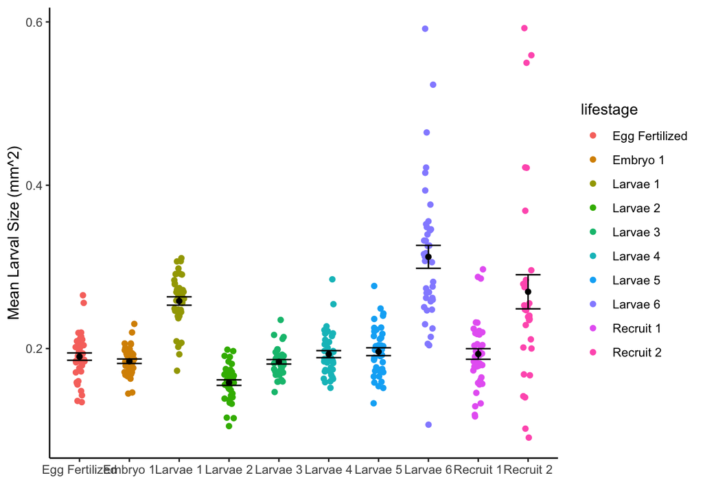

```r
df %>%
  ggplot(aes(x = lifestage, y = area, color = lifestage)) +
  labs(x = "",y = "Mean Larval Size (mm^2)") +
geom_jitter(width = 0.1) +                                            # Plot all points
  stat_summary(fun.data = mean_cl_normal, fun.args = list(mult = 1),    # Plot standard error
               geom = "errorbar", color = "black", width = 0.5) +
  stat_summary(fun.y = mean, geom = "point", color = "black") + # Plot mean
  theme_classic()
```

Present means and standard error of each group and save summary table

```r
df%>%
  group_by(lifestage, hpf)%>%
  summarize(n=length(area),
            Mean=format(round(mean(area), 3), 3),
            SE=format(round(sd(area)/sqrt(length(area)),3),3))%>%
  rename(Lifestage=lifestage, HPF=hpf)%>%
  kbl(caption="Descriptive statistics of larval size across ontogeny")%>%
  kable_classic(full_width=FALSE, html_font="Arial")%>%
  row_spec(0, bold = TRUE)
```

Descriptive statistics of larval size across ontogeny

| Lifestage | HPF | n | Mean | SE |
| --- | --- | --- | --- | --- |
| Egg Fertilized | 1 | 40 | 0.19 | 0.004 |
| Embryo 1 | 5 | 40 | 0.184 | 0.003 |
| Larvae 1 | 38 | 40 | 0.258 | 0.005 |
| Larvae 2 | 65 | 40 | 0.158 | 0.003 |
| Larvae 3 | 93 | 40 | 0.184 | 0.003 |
| Larvae 4 | 163 | 40 | 0.193 | 0.004 |
| Larvae 5 | 183 | 40 | 0.196 | 0.005 |
| Larvae 6 | 231 | 40 | 0.312 | 0.014 |
| Recruit 1 | 183 | 40 | 0.193 | 0.006 |
| Recruit 2 | 231 | 33 | 0.27 | 0.021 |

```r
#need to output to csv
df%>%
  group_by(lifestage, hpf)%>%
  summarize(n=length(area),
            Mean=format(round(mean(area), 3), 3),
            SE=format(round(sd(area)/sqrt(length(area)),3),3))%>%
  rename(Lifestage=lifestage, HPF=hpf)%>%
  write_csv(., "Mcap2020/Output/Physiology/larval_size_table.csv")
```

## Plot data as a scatterplot

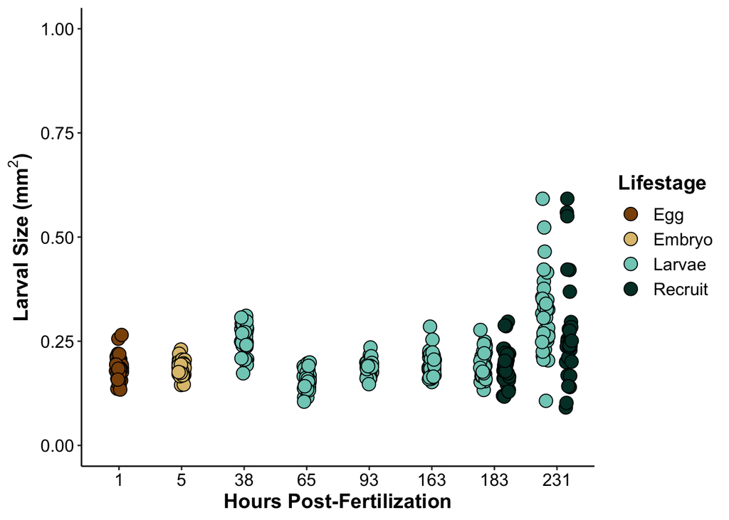

```r
df$hpf<-as.factor(df$hpf)
size_plot<-df %>%
    ggplot(., aes(x = hpf, y = area)) +
    #geom_boxplot(outlier.size = 0) +
    geom_smooth(method="loess", se=TRUE, fullrange=TRUE, level=0.95, color="black") +
    geom_point(aes(fill=group, group=group), pch = 21, size=4, position = position_jitterdodge(0.1)) +
    xlab("Hours Post-Fertilization") +
    scale_fill_manual(name="Lifestage", values=c("#8C510A", "#DFC27D","#80CDC1", "#003C30"))+
    ylab(expression(bold(paste("Larval Size (mm"^2, ")"))))+
    ylim(0,1)+
    theme_classic() +
    theme(
      legend.position="right",
      axis.title=element_text(face="bold", size=14),
      axis.text=element_text(size=12, color="black"),
      legend.title=element_text(face="bold", size=14),
      legend.text=element_text(size=12)
      ); size_plot
```

```r
#EGG: #8C510A
#EMBRYO: #DFC27D
#LARVAE: #80CDC1
#RECRUIT: #003C30

#COLORS TO TRY FROM BRBG: "#543005" "#8C510A" "#BF812D" "#DFC27D" "#F6E8C3" "#F5F5F5" "#C7EAE5" "#80CDC1" "#35978F" "#01665E" "#003C30"

#ggsave("Mcap2020/Figures/Physiology/SymbiontCounts.png", symb_plot, dpi=300, w=8.5, h=5, units="in")
```

## Plot data as box plot

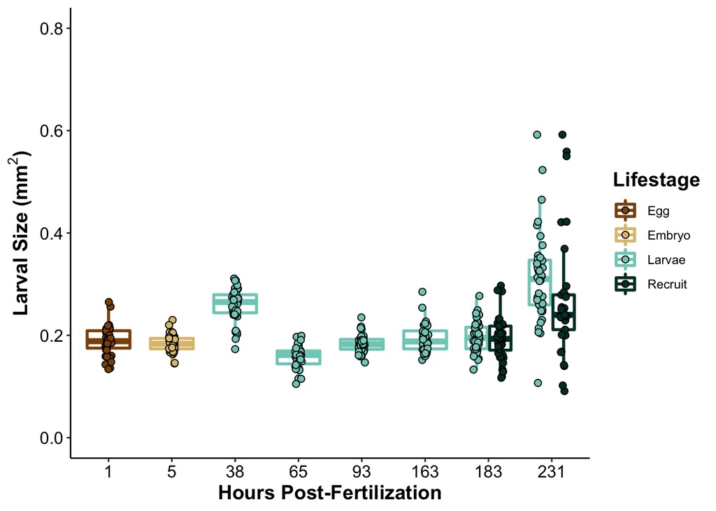

```r
size_plot2<-df %>%
    ggplot(., aes(x = hpf, y = area)) +
    geom_boxplot(aes(color=group), outlier.size = 0, lwd=1) +
    #geom_smooth(method="loess", se=TRUE, fullrange=TRUE, level=0.95, color="black") +
    geom_point(aes(fill=group), pch = 21, size=2, position = position_jitterdodge(0.1)) +
    xlab("Hours Post-Fertilization") +
    scale_fill_manual(name="Lifestage", values=c("#8C510A", "#DFC27D","#80CDC1", "#003C30"))+
    scale_color_manual(name="Lifestage", values=c("#8C510A", "#DFC27D","#80CDC1", "#003C30"))+
    ylab(expression(bold(paste("Larval Size (mm"^2, ")"))))+
    ylim(0, 0.8)+
    theme_classic() +
    #geom_text(label="A", x=1, y=2500, size=4, color="black")+ #egg
    #geom_text(label="A", x=2, y=2500, size=4, color="black")+ #embryo 1
    #geom_text(label="A", x=3, y=2500, size=4, color="black")+ #larvae 1
    #geom_text(label="AB", x=4, y=4100, size=4, color="black")+ #larvae 2
    #geom_text(label="AB", x=5, y=4100, size=4, color="black")+ #larvae 3
    #geom_text(label="AB", x=6, y=4100, size=4, color="black")+ #larvae 4
    #geom_text(label="BC", x=6.8, y=4500, size=4, color="black")+ #larvae 5
    #geom_text(label="CD", x=7.2, y=6500, size=4, color="black")+ #recruit 1
    #geom_text(label="D", x=7.8, y=6500, size=4, color="black")+ #larvae6
    #geom_text(label="D", x=8.2, y=8700, size=4, color="black")+ #recruit2
    theme(
      legend.position="right",
      axis.title=element_text(face="bold", size=14),
      axis.text=element_text(size=12, color="black"),
      legend.title=element_text(face="bold", size=14)
      ); size_plot2
```

```r
ggsave("Mcap2020/Figures/Physiology/LarvalSize_Box.png", size_plot2, dpi=300, w=8.5, h=5, units="in")
```

# Statistical analysis

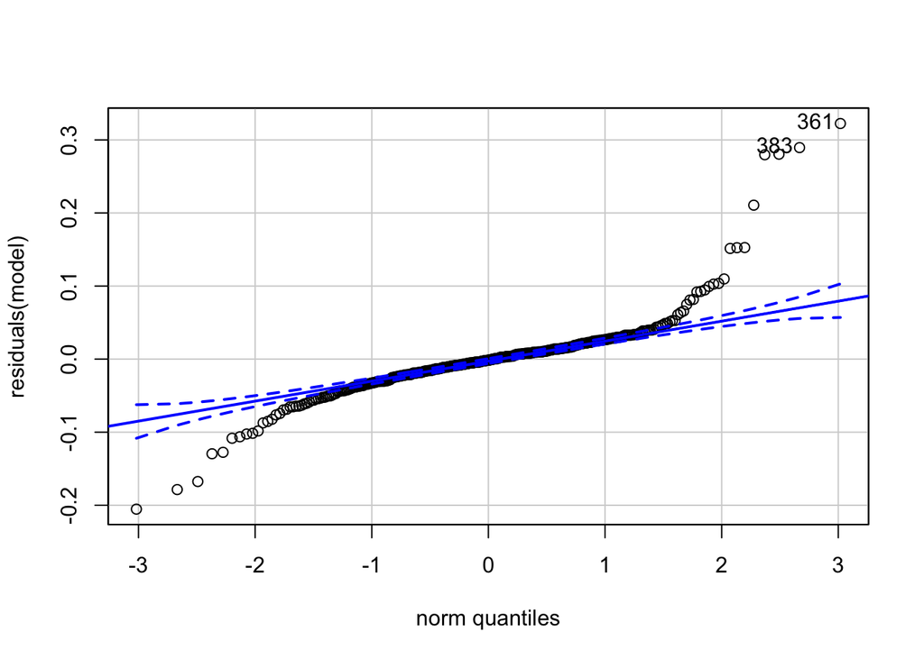

```
## [1] 361 383
```

```r
model<-aov(area~lifestage, data=df)
qqPlot(residuals(model))
```

```r
leveneTest(residuals(model)~lifestage, data=df)
```

```
## Levene's Test for Homogeneity of Variance (center = median)
##        Df F value    Pr(>F)
## group   9  12.196 < 2.2e-16 ***
##       383
## ---
## Signif. codes:  0 '***' 0.001 '**' 0.01 '*' 0.05 '.' 0.1 ' ' 1
```

Violation in normality and variance assumptions. Conduct non-parametric test (Kruskal Wallis).

```r
kruskal.test(area~lifestage, data=df)
```

```
##
##  Kruskal-Wallis rank sum test
##
## data:  area by lifestage
## Kruskal-Wallis chi-squared = 191.71, df = 9, p-value < 2.2e-16
```

Significant effect of lifestage on larval size.

View posthoc comparisons for differences between lifestages.

```r
emm = emmeans(model, ~ lifestage)
cld(emm, Letters=c(LETTERS)) #letter display
```

```
##  lifestage      emmean      SE  df lower.CL upper.CL .group
##  Larvae 2        0.158 0.00813 383    0.142    0.174  A
##  Larvae 3        0.184 0.00813 383    0.168    0.200  AB
##  Embryo 1        0.184 0.00813 383    0.169    0.200  AB
##  Egg Fertilized  0.190 0.00813 383    0.174    0.206  AB
##  Larvae 4        0.193 0.00813 383    0.177    0.209  AB
##  Recruit 1       0.193 0.00813 383    0.177    0.209  AB
##  Larvae 5        0.196 0.00813 383    0.180    0.212   B
##  Larvae 1        0.258 0.00813 383    0.242    0.274    C
##  Recruit 2       0.270 0.00895 383    0.252    0.287    C
##  Larvae 6        0.312 0.00813 383    0.296    0.328     D
##
## Confidence level used: 0.95
## P value adjustment: tukey method for comparing a family of 10 estimates
## significance level used: alpha = 0.05
```

# Test for correlation between symbiont cell density and larval size

Generate data frame with summarised size and cell density information for each tube (n=4 per sampling timepoint).

```r
counts<-read.csv("Mcap2020/Output/Physiology/calculated_densities.csv")

counts<-counts%>%
  dplyr::select(tube.ID, lifestage, group, hpf, cells.ind)

area<-df%>%
  group_by(tube.ID)%>%
  summarise(mean_area=mean(area))

area$tube.ID<-as.factor(area$tube.ID)
counts$hpf<-as.factor(counts$hpf)

corr<-left_join(counts, area)
```

Plot correlation between cell counts (cells per individual) and larval size (area mm^2).

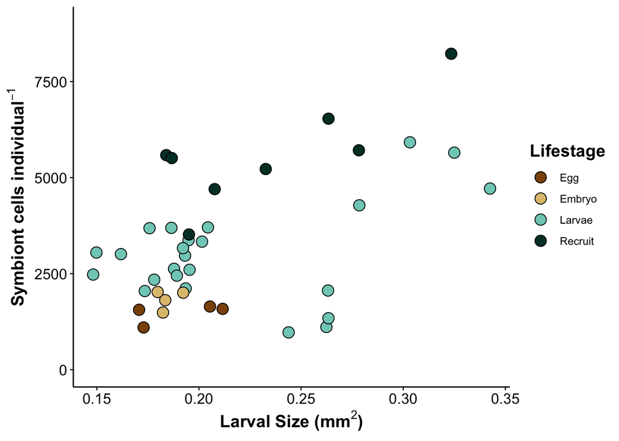

```r
correlation<-corr %>%
    ggplot(., aes(x = mean_area, y = cells.ind)) +
    #geom_smooth(method="gam", se=TRUE, fullrange=TRUE, level=0.95, color="black", fill="gray") +
    geom_point(aes(fill=group), pch = 21, size=4) +
    xlab(expression(bold(paste("Larval Size (mm"^2, ")")))) +
    scale_fill_manual(name="Lifestage", values=c("#8C510A", "#DFC27D","#80CDC1", "#003C30"))+
    scale_color_manual(name="Lifestage", values=c("#8C510A", "#DFC27D","#80CDC1", "#003C30"))+
    xlab(expression(bold(paste("Larval Size (mm"^2, ")"))))+
    ylab(expression(bold(paste("Symbiont cells individual"^-1))))+
    ylim(0, 9000)+
    theme_classic() +
    theme(
      legend.position="right",
      axis.title=element_text(face="bold", size=14),
      axis.text=element_text(size=12, color="black"),
      legend.title=element_text(face="bold", size=14)
      ); correlation
```

```r
ggsave("Mcap2020/Figures/Physiology/Size_Cells_Correlation.png", correlation, dpi=300, w=8.5, h=5, units="in")
```

Test relationship with a spearman correlation.

```r
test<-cor.test(corr$mean_area, corr$cells.ind, method=c("spearman"))
test
```

```
##
##  Spearman's rank correlation rho
##
## data:  corr$mean_area and corr$cells.ind
## S = 6658, p-value = 0.01753
## alternative hypothesis: true rho is not equal to 0
## sample estimates:
##       rho
## 0.3754221
```

Significant correlation between size and cell counts. r=0.37

# Visualize normalized symbiont cell counts using summarized data at the level of the tube.

Generate number of symbiont cells per mm^2 area.

```r
corr<-corr%>%
  mutate(counts_area=cells.ind/mean_area)
```

Plot cells per mm^2 as a boxplot.

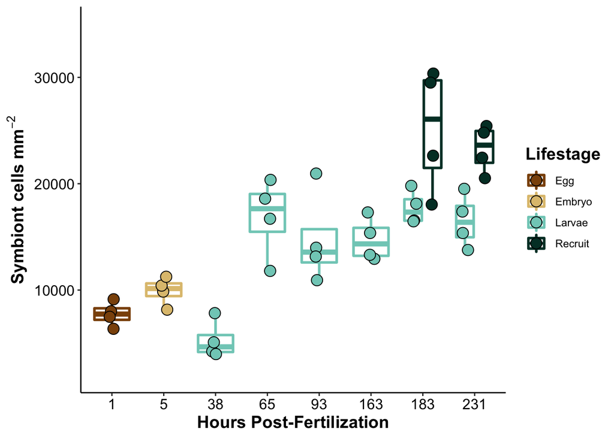

```r
cells_size_plot<-corr %>%
    ggplot(., aes(x = hpf, y = counts_area)) +
    geom_boxplot(aes(color=group), outlier.size = 0, lwd=1) +
    geom_point(aes(fill=group), pch = 21, size=4, position = position_jitterdodge(0.4)) +
    xlab("Hours Post-Fertilization") +
    scale_fill_manual(name="Lifestage", values=c("#8C510A", "#DFC27D","#80CDC1", "#003C30"))+
    scale_color_manual(name="Lifestage", values=c("#8C510A", "#DFC27D","#80CDC1", "#003C30"))+
    ylab(expression(bold(paste("Symbiont cells mm"^-2))))+
    ylim(2000, 35000)+
    theme_classic() +
    theme(
      legend.position="right",
      axis.title=element_text(face="bold", size=14),
      axis.text=element_text(size=12, color="black"),
      legend.title=element_text(face="bold", size=14)
      ); cells_size_plot
```

```r
ggsave("Mcap2020/Figures/Physiology/Normalized_counts_size.png", cells_size_plot, dpi=300, w=8.5, h=5, units="in")
```

Analyze differences in normalized cell counts by timepoint. Normality and variance assumtions pass. There is a significant effect of timepoint on cell counts normalized to average size.

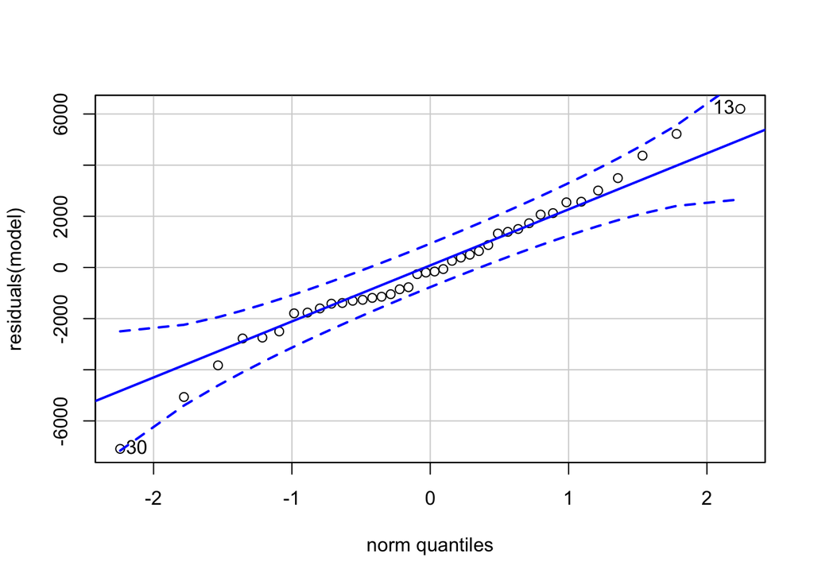

```
## [1] 30 13
```

```r
model<-aov(counts_area~lifestage, data=corr)
qqPlot(residuals(model))
```

```r
leveneTest(residuals(model)~lifestage, data=corr)
```

```
## Levene's Test for Homogeneity of Variance (center = median)
##       Df F value  Pr(>F)
## group  9  2.0651 0.06611 .
##       30
## ---
## Signif. codes:  0 '***' 0.001 '**' 0.01 '*' 0.05 '.' 0.1 ' ' 1
```

```r
summary(model)
```

```
##             Df    Sum Sq   Mean Sq F value   Pr(>F)
## lifestage    9 1.430e+09 158842022   17.51 1.18e-09 ***
## Residuals   30 2.721e+08   9069331
## ---
## Signif. codes:  0 '***' 0.001 '**' 0.01 '*' 0.05 '.' 0.1 ' ' 1
```

View posthoc differences.

```r
emm = emmeans(model, ~ lifestage)
cld(emm, Letters=c(LETTERS)) #letter display
```

```
##  lifestage      emmean   SE df lower.CL upper.CL .group
##  Larvae 1         5285 1506 30     2210     8360  A
##  Egg Fertilized   7746 1506 30     4671    10821  AB
##  Embryo 1         9923 1506 30     6848    12999  ABC
##  Larvae 4        14732 1506 30    11657    17807   BCD
##  Larvae 3        14756 1506 30    11681    17832   BCD
##  Larvae 6        16510 1506 30    13435    19585    CDE
##  Larvae 2        16867 1506 30    13791    19942    CDE
##  Larvae 5        17732 1506 30    14657    20807     DE
##  Recruit 2       23301 1506 30    20226    26376      EF
##  Recruit 1       25137 1506 30    22061    28212       F
##
## Confidence level used: 0.95
## P value adjustment: tukey method for comparing a family of 10 estimates
## significance level used: alpha = 0.05
```

Generate summary table of descriptive statistics.

```r
#need to output to csv
corr%>%
  group_by(group, hpf)%>%
  summarize(n=length(counts_area),
            Mean=format(round(mean(counts_area), 0), 0),
            SE=format(round(sd(counts_area)/sqrt(length(counts_area)),0),0))%>%
  rename(Lifestage=group, HPF=hpf)%>%
  write_csv(., "Mcap2020/Output/Physiology/normalized_size_cells_summary.csv")
```